# MSDS-6373-Project1

Ryan H, Jason M

5/30/2022

Read in data first

```r
life_exp_loc <- 'Data/LifeExpectancyData.csv'
# Create the data frame that will not be modified
life_exp <- read.csv(life_exp_loc, sep=',', header = TRUE)
```

# EDA

### Start looking at missing data to get an idea of what to expect

```r
# Create data frame of rows that contain missing data
rows_with_na <- life_exp[rowSums(is.na(life_exp)) > 0,] # 1,289 rows...

# Count how many na's per column
cols_with_na <- life_exp[is.na(life_exp$Schooling),]

# Columns with # of 'na' values
# -----------------------------
# Life.expectancy: 10 *
# Adult.Mortality: 10
# Alcohol: 194
# Hepatitis.B: 553 *
# BMI: 34
# Polio: 19
# Total.expenditure: 226
# Diphtheria: 19
# GDP: 448
# Population: 652 *
# thiness1-19years: 34
# thiness5-9years: 34
# Income.comp.of.resc: 167
# Schooling: 163
# -----------------------------
```

- The two biggest column with the most amount of data missing is Hepatitis.B and the Population.
- Since Life.expectancy is the value we are trying to predict, the rows that have missing values for Life.expectancy should not be used in the training model
- Will need to do some more EDA and keep an eye on these columns to see how big of an impact they have.
- A lot of 0 values for infant deaths… That doesn’t seem right. Looks like something that could throw off the data.
- In general keep an eye out if mortality rate in general has any affect
- Also keep an eye on Percentage.expenditure. It’s zero for a lot of countries that are considered developed, and there is another column for total spending on health for each country.

### Create a subset of data without the rows containing ‘na’ in Life.expectancy

### And also seperate the training from test set 85/15

```r
# Boolean value that if set to TRUE will split the data 85/15 here
# If FALSE, we will split later
# Will still use the same variable names
split_data <- FALSE
```

```r
# New DF with no NA Life.expectrancies
life_exp_v02 <- life_exp[!is.na(life_exp$Life.expectancy),]

if (split_data == TRUE) {
  # Sperate the data
  set.seed(1536)
  split_size <- floor(0.85 * nrow(life_exp_v02))
  train_ind <- sample(seq_len(nrow(life_exp_v02)), size = split_size)
  life_exp_train_v01 <- life_exp_v02[train_ind,]
  life_exp_test <- life_exp_v02[-train_ind,]
} else {
  life_exp_train_v01 <- life_exp_v02
  life_exp_test <- data.frame() # Empty data frame to be populated later
}
```

Make some modifications to the columns. Changing Names of columns to be more relative and change the data types of some columns

```r
# New version
life_exp_train_v02 <- life_exp_train_v01

# I know I can write this as one line, but this reads better
colnames(life_exp_train_v02)[9] <- c("Hep.B.Shots")
colnames(life_exp_train_v02)[10] <- c("Measle_Cases") # Per 1k
colnames(life_exp_train_v02)[13] <- c("Polio_Shots") # Percent Amoung 1yr olds
colnames(life_exp_train_v02)[14] <- c("Total_health_Spending") # Percent of total gov expenditure
colnames(life_exp_train_v02)[15] <- c("Diphtheria_shots") # Percent among 1yr olds
colnames(life_exp_train_v02)[16] <- c("HIV_AIDS_birth_deaths") # Per 1k

# Change Country, Year, and Status columns to as.factor
tmp_chng_col <- c("Country", "Year", "Status")
life_exp_train_v02[tmp_chng_col] <- lapply(life_exp_train_v02[tmp_chng_col], as.factor)
```

Basic data prepping done. We want to now start to look at the data and check for collinearity, outliers, or possibly data that could benifit from log transformation or data that may repeat.

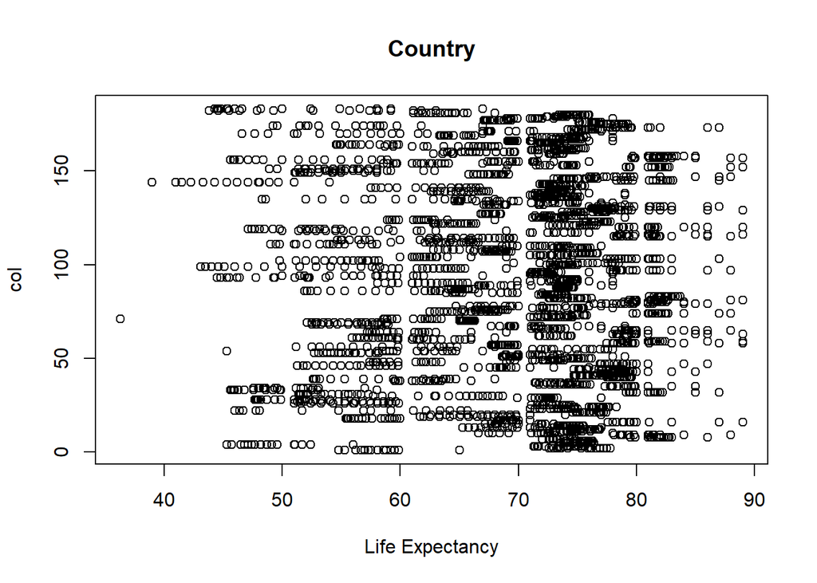

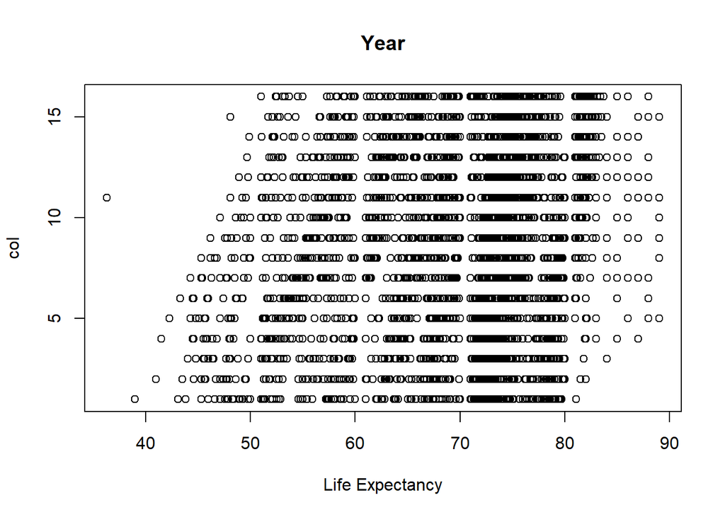

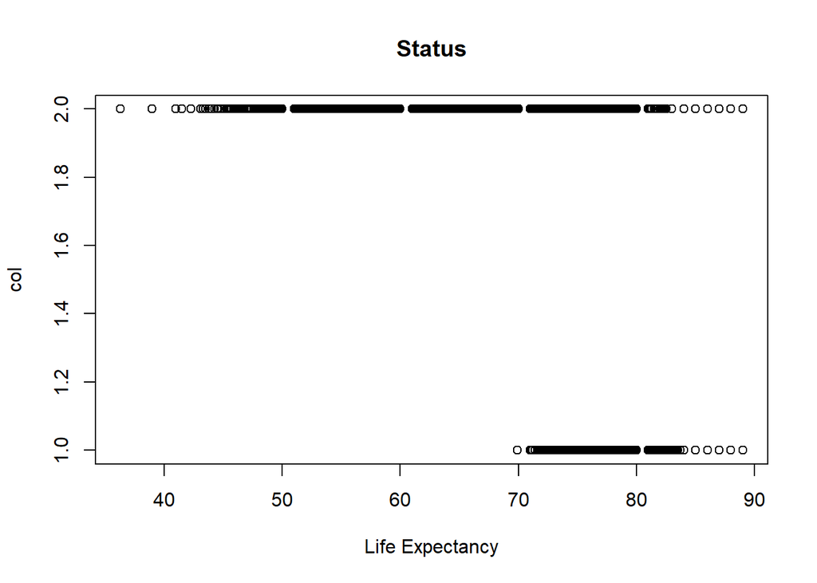

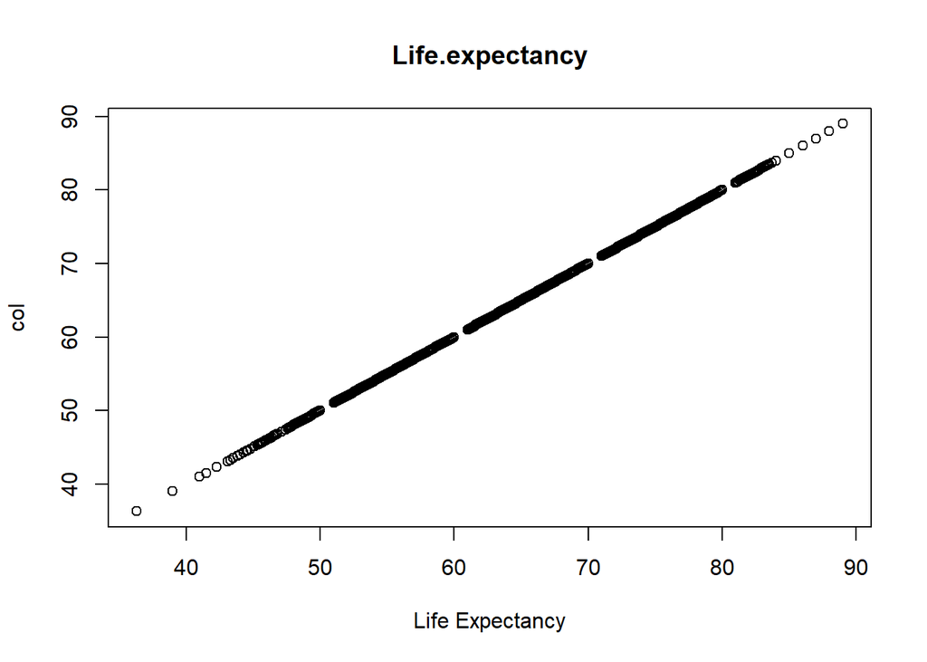

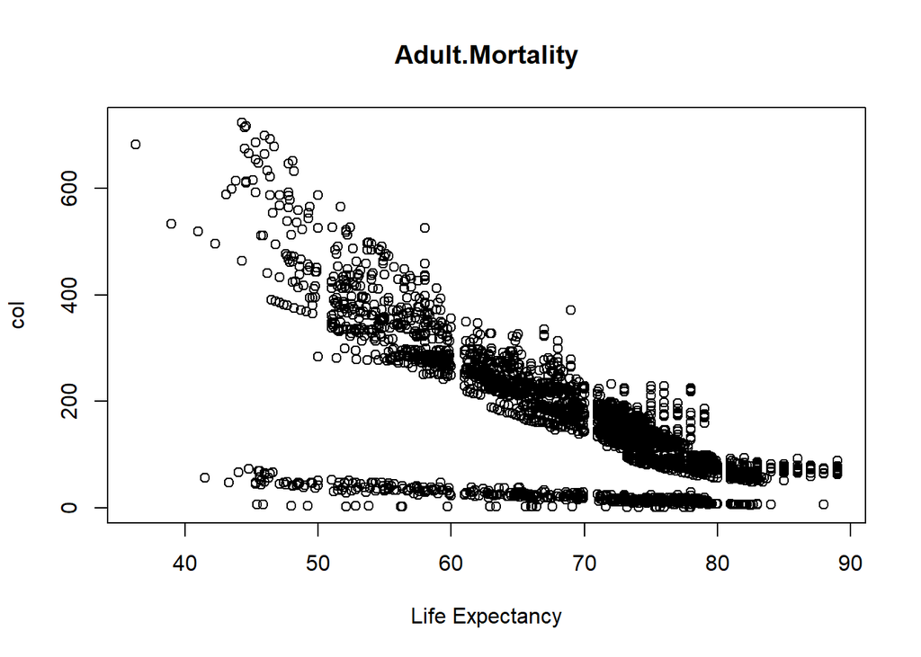

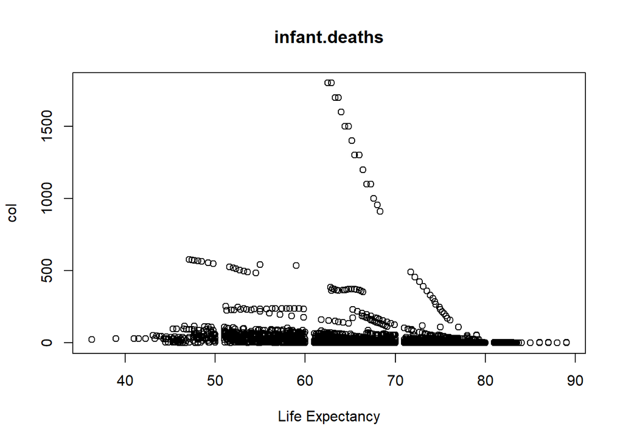

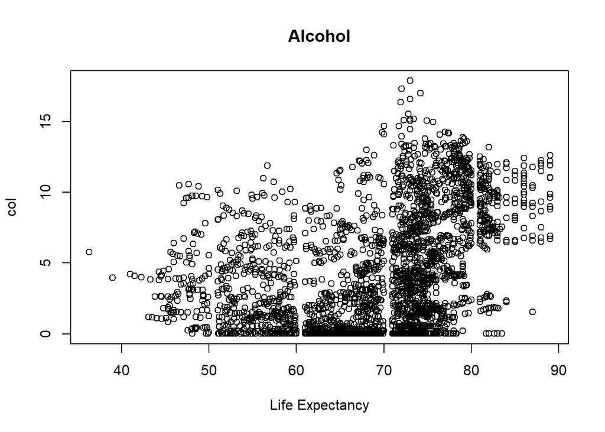

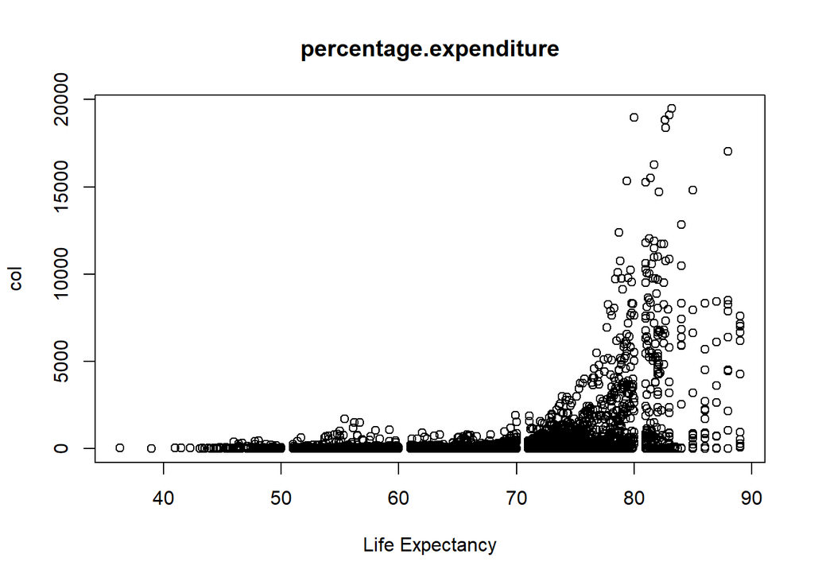

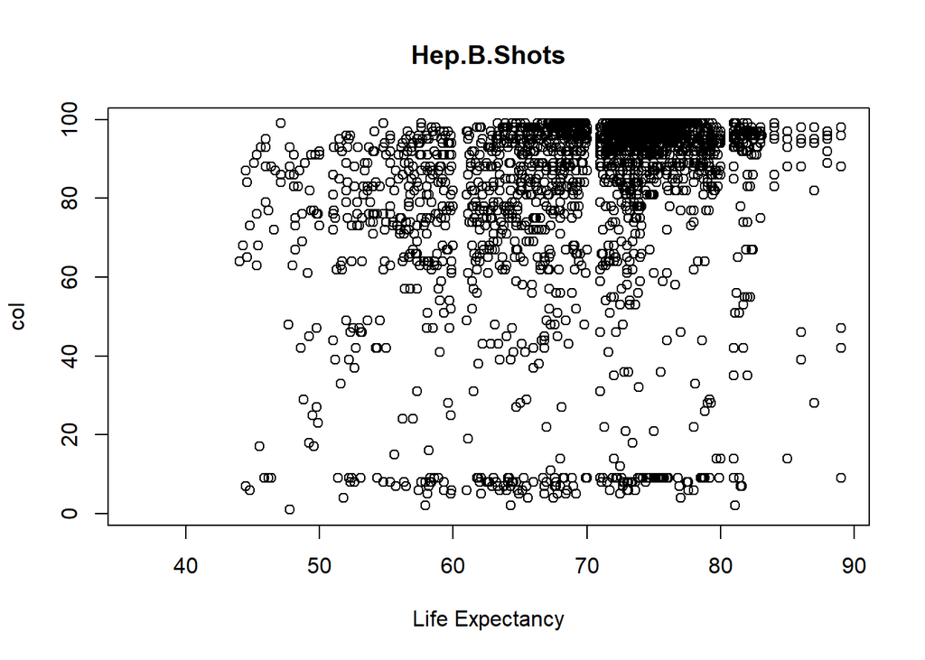

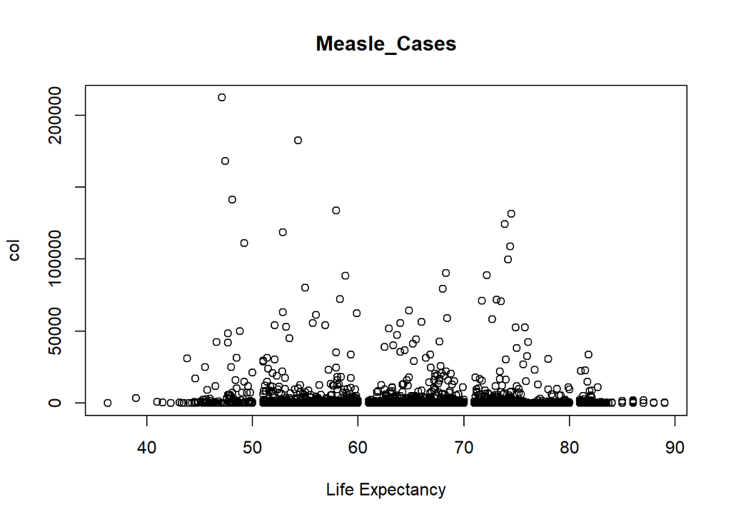

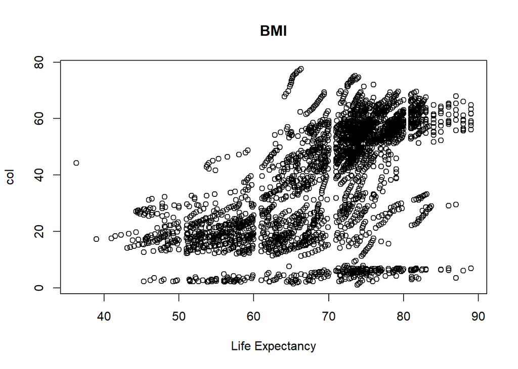

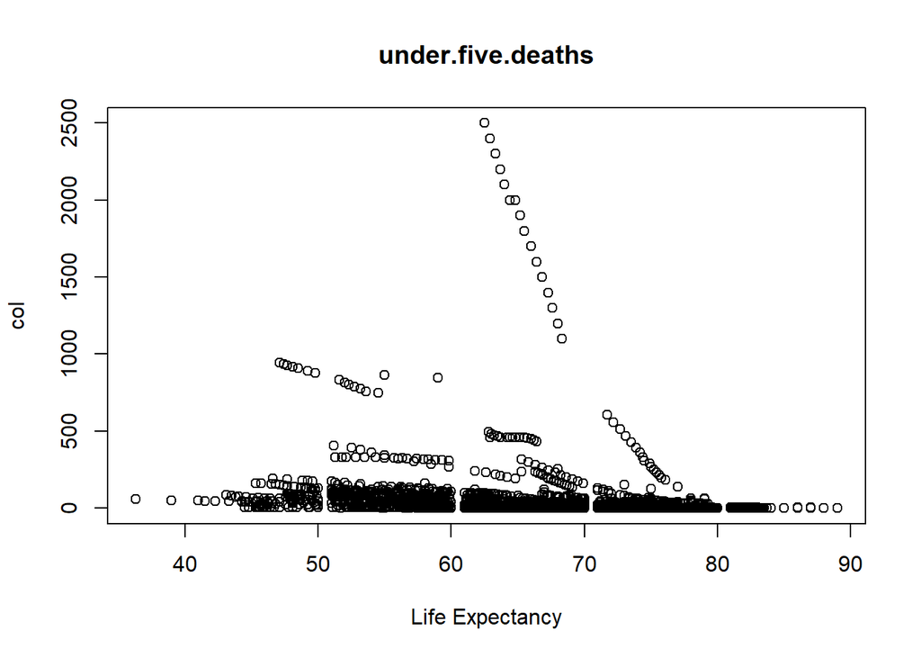

[10 more figures not shown]

```r
# Create a v03
life_exp_train_v03 <- life_exp_train_v02

# Loop through the categories and plot them to get a better understanding of the distribution
col_names <- names(life_exp_train_v03)
col_names_index <- 1

for (col in life_exp_train_v03) {
  plot(life_exp_train_v03$Life.expectancy, col,
       main=col_names[col_names_index], xlab="Life Expectancy")
  col_names_index <- col_names_index + 1
}
```

### Notes:

- Infant Deaths and under.five.deaths are strongly related
- BMI almost looks like it can be broken down into 3 categories
- Population has some extreme outliers. Further research says it’s all from India
- There is some commonality between charts for categories that record immunization (shots)
- Percentage.expenditure, GDP look to be quadratic

Apply a log transformation to the 2 charts that look to be quadratic. Also drop the 5-9 Thinness. It’s the same chart as the 10-19 thinness chart.

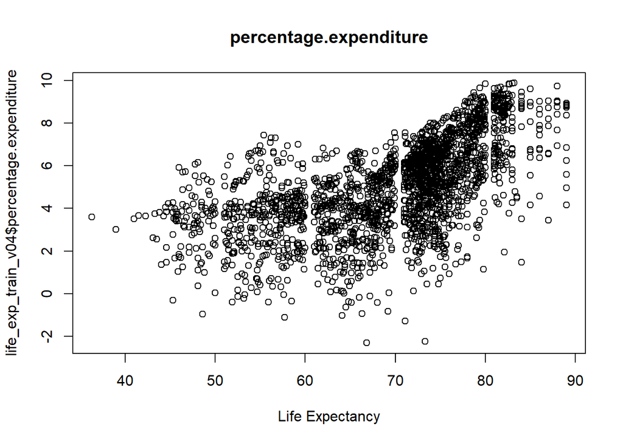

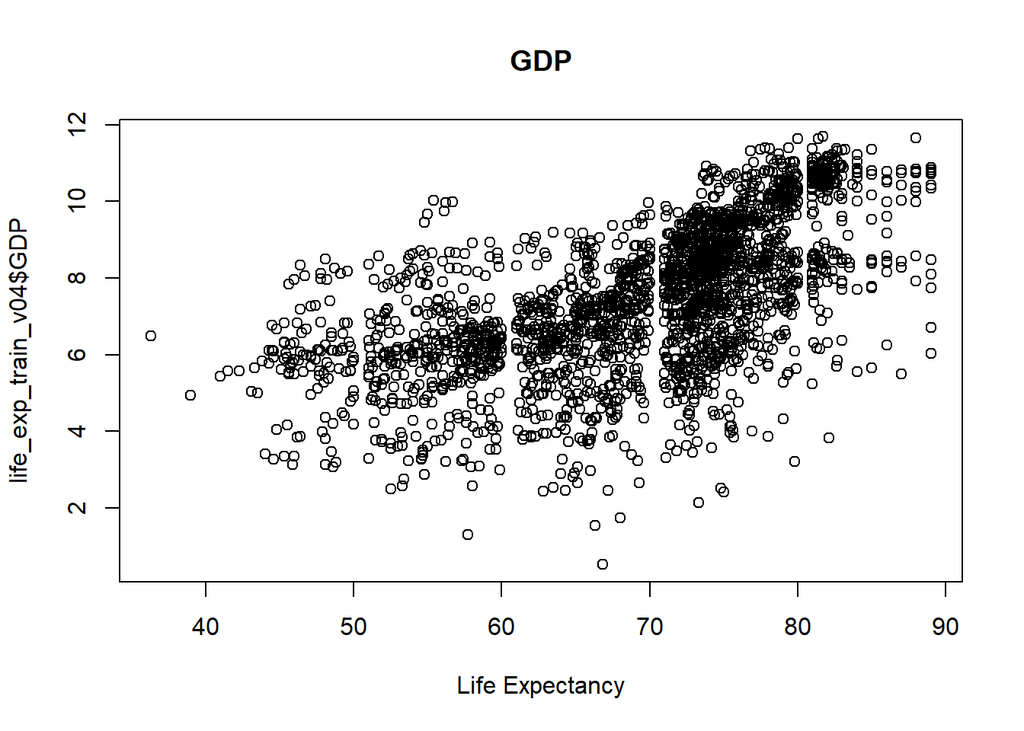

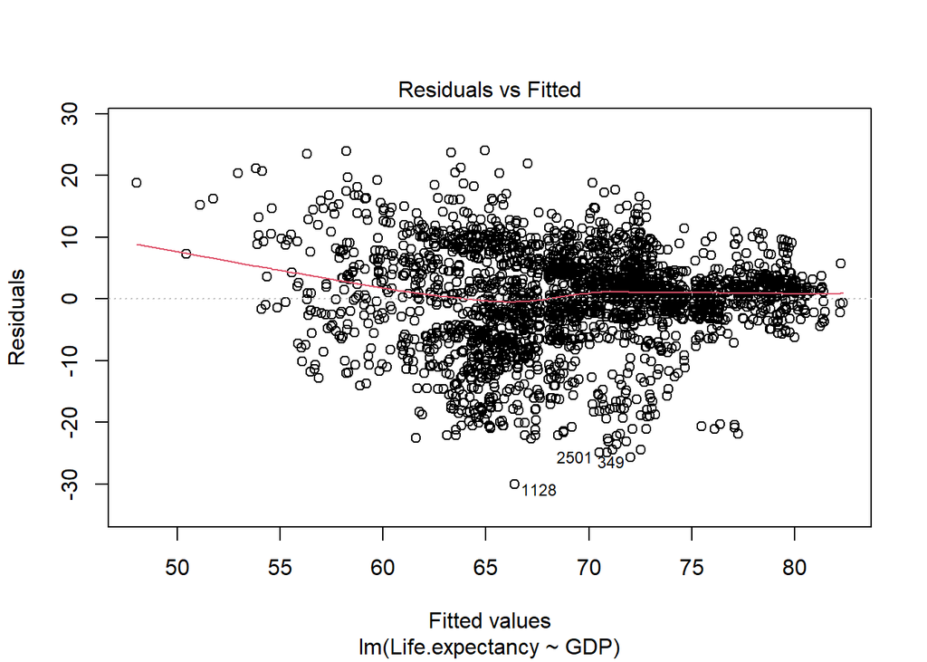

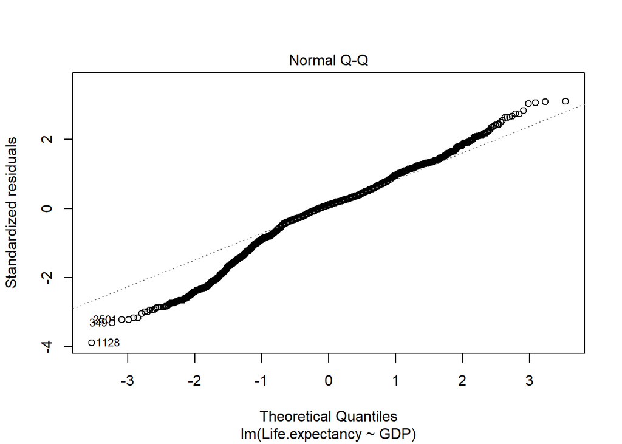

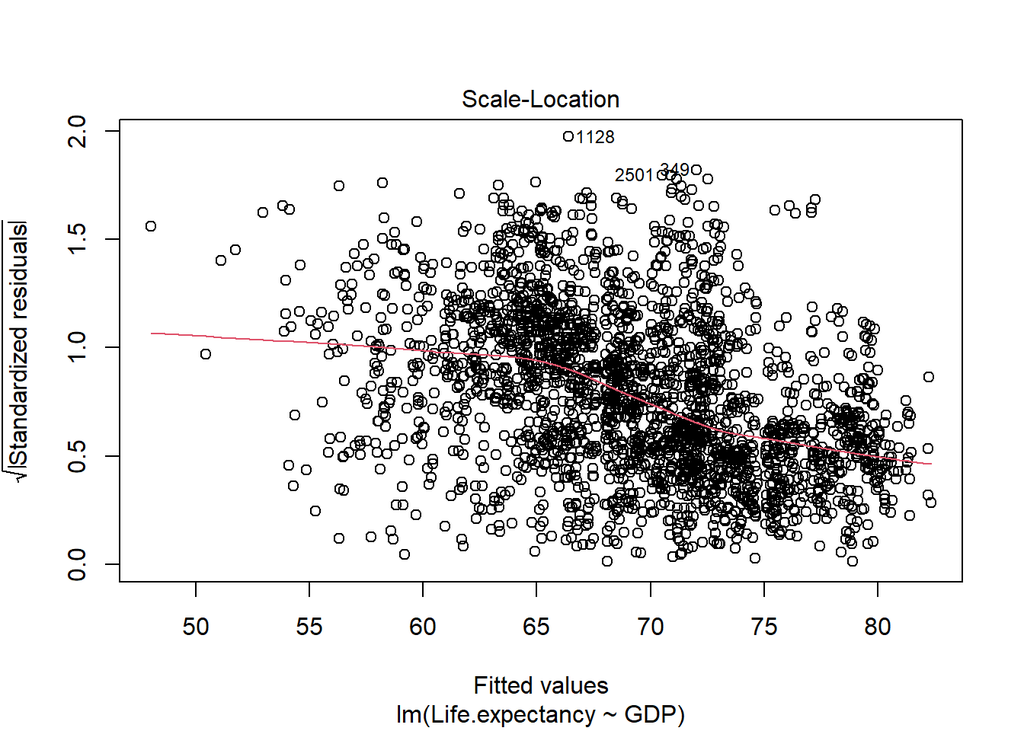

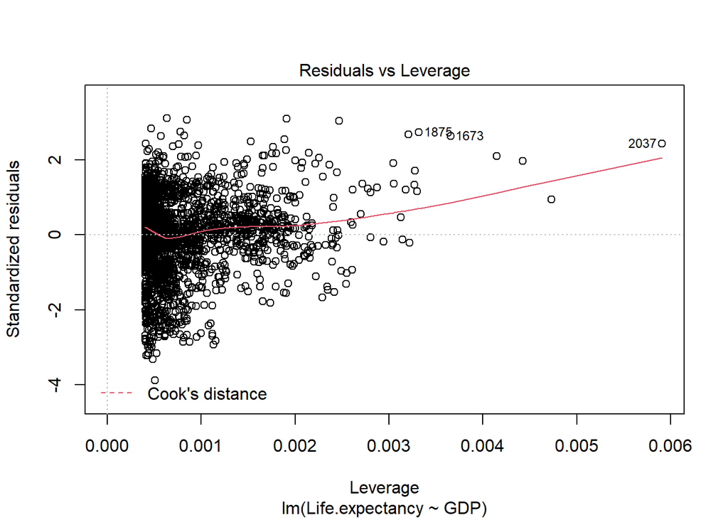

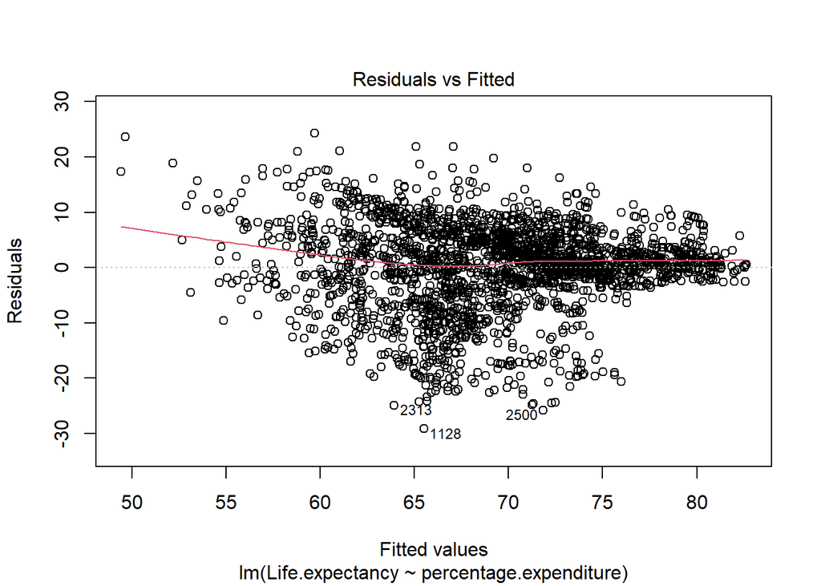

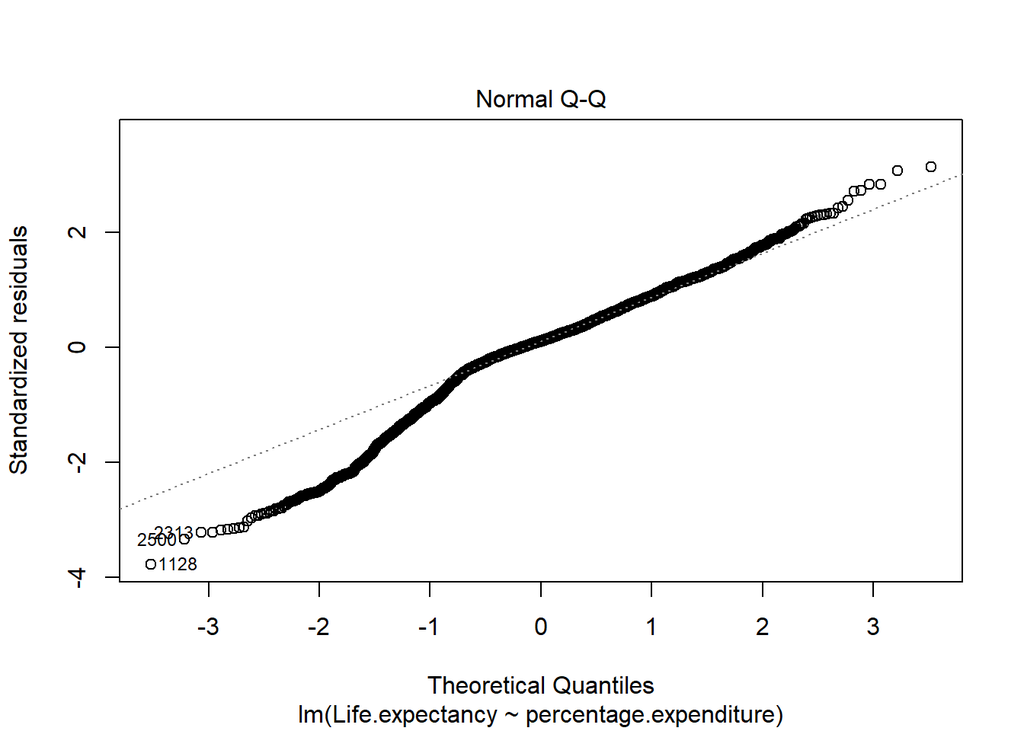

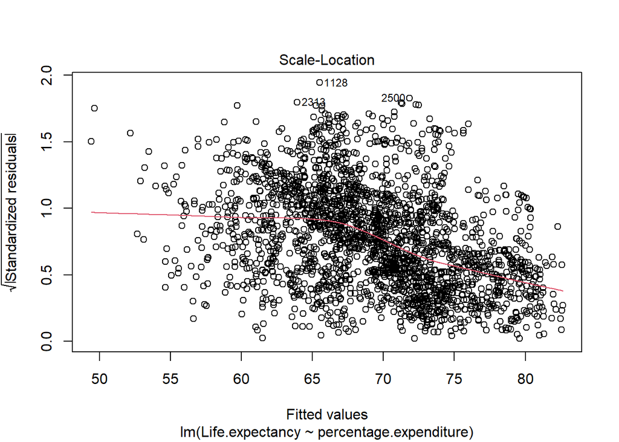

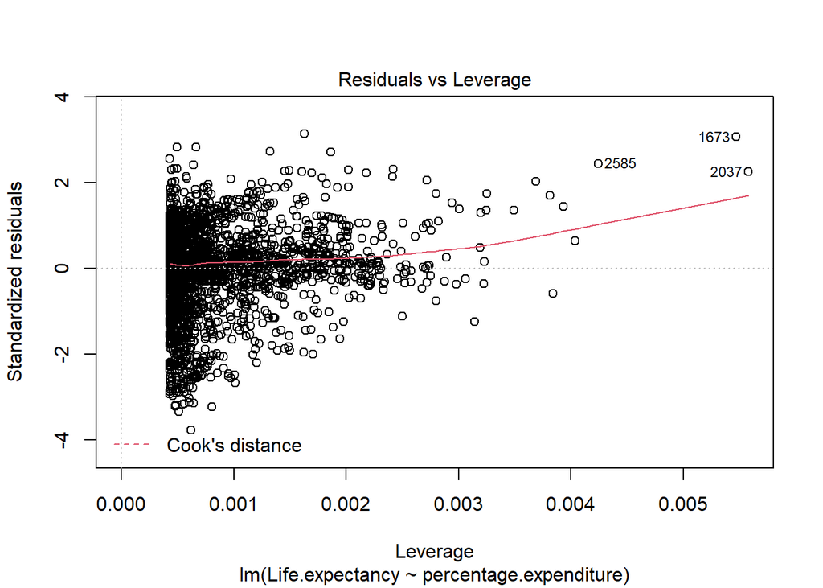

```r
# Version v04
life_exp_train_v04 <- subset(life_exp_train_v03, select=-thinness.5.9.years) # Removes Thiness 5-9 col

# Log transform Percentage.expenditure, GDP,
life_exp_train_v04$percentage.expenditure <- log(life_exp_train_v04$percentage.expenditure)
life_exp_train_v04$GDP <- log(life_exp_train_v04$GDP)

# Remove INF values in the percentage.expendature
life_exp_train_v04$percentage.expenditure[is.infinite(life_exp_train_v04$percentage.expenditure)] <- NA

# Check the charts after transformation
# It's only two, I don't need to loop through this
plot(life_exp_train_v04$Life.expectancy, life_exp_train_v04$percentage.expenditure,
     main="percentage.expenditure", xlab="Life Expectancy")
plot(life_exp_train_v04$Life.expectancy, life_exp_train_v04$GDP,
     main="GDP", xlab="Life Expectancy")

log_gdp_fit <- lm(Life.expectancy~GDP, data=life_exp_train_v04)
plot(log_gdp_fit)

log_pe_fit <- lm(Life.expectancy~percentage.expenditure, data=life_exp_train_v04, na.action=na.omit)
plot(log_pe_fit)
```

Create a correlation table with only the continous data https://cran.r-project.org/web/packages/olsrr/vignettes/regression_diagnostics.html

```r
# Create a version with only numerical values
life_exp_train_v04.1 <- subset(life_exp_train_v04, select=c(-Country, -Year, -Status))

# Using the corrplot package
# Using pairwise.complete.obs to ignore the na values, but still include the row
cor_num_only <- cor(life_exp_train_v04.1, use='pairwise.complete.obs')
```

There was a strong correlation between

- GDP and Percentage.expenditure (when ran with v004) @.94
- under.five.deaths and infant deaths @.99
- HepB and Diphtheria shots @.61

I believe the path forward will be dropping Percentage.expenditure, infant.deaths because they have a lower correlation with Life.Expectancy. The shots will stay and the variable selection will decide if they stay or go.

```r
# v006
# Remove Percentage.expedeture and infant.deaths
life_exp_train_v05 <- subset(life_exp_train_v04, select=c(-infant.deaths, -percentage.expenditure))
```

Create Universal model that could be used later if needed

```r
# Base model with no selection process
model_orig <- lm(Life.expectancy~., data=life_exp_train_v05)
```

### Stepwise Selction

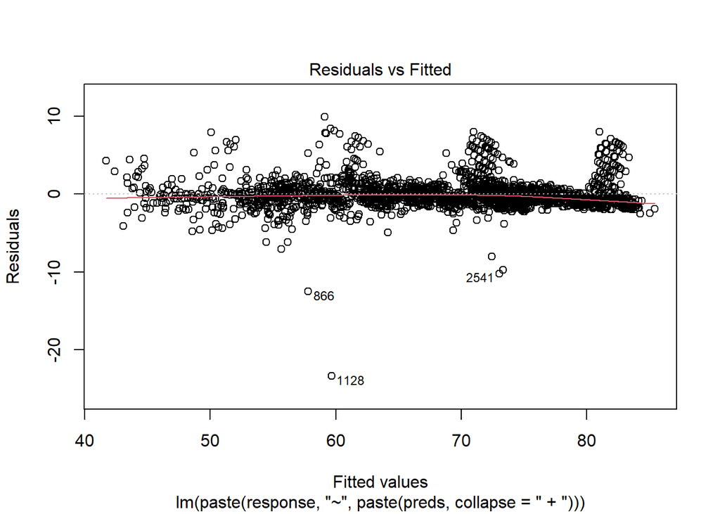

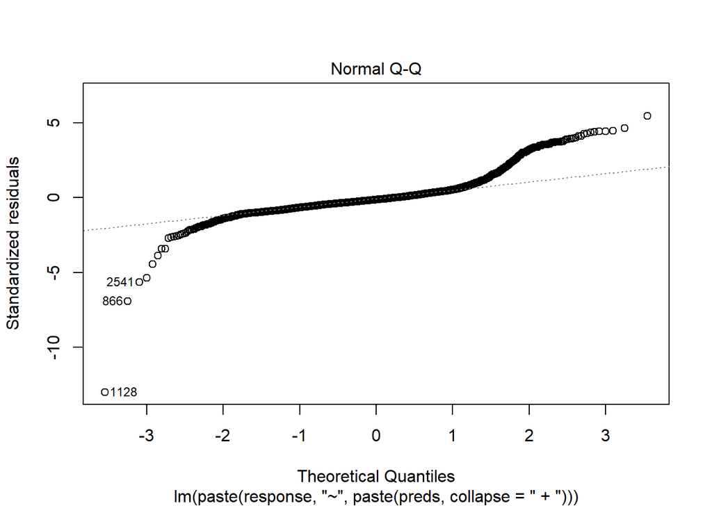

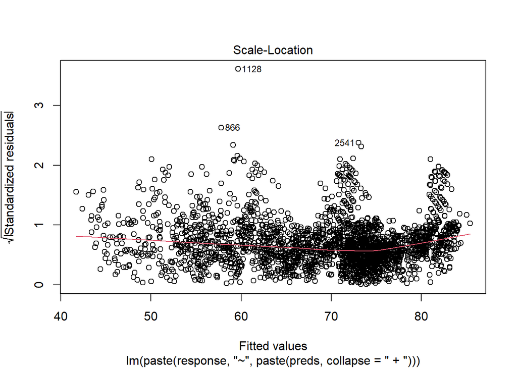

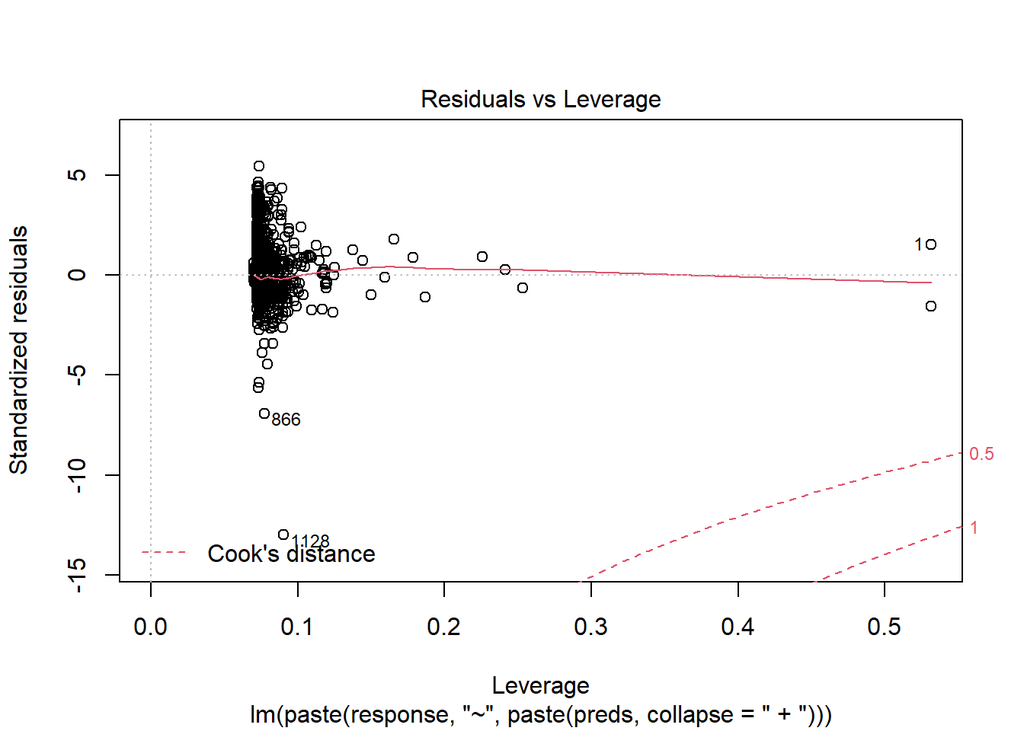

```r
# Not Using AIC
model_stpwise_p <- ols_step_both_p(model_orig)
model_stpwise_p_df <- subset(life_exp_train_v05, select=c('Country', 'Adult.Mortality',
  'Income.composition.of.resources', 'Schooling', 'Year', 'HIV_AIDS_birth_deaths',
  'Diphtheria_shots', 'Measle_Cases'))

# Using AIC
model_stpwise_aic <- ols_step_both_aic(model_orig, details=FALSE)
model_stpwise_aic_df <- subset(life_exp_train_v05, select=c('Country', 'Hep.B.Shots',
  'Population', 'Alcohol', 'Year', 'HIV_AIDS_birth_deaths', 'GDP', 'thinness..1.19.years',
  'Schooling', 'under.five.deaths', 'Income.composition.of.resources'))

plot(model_stpwise_p$model)
```

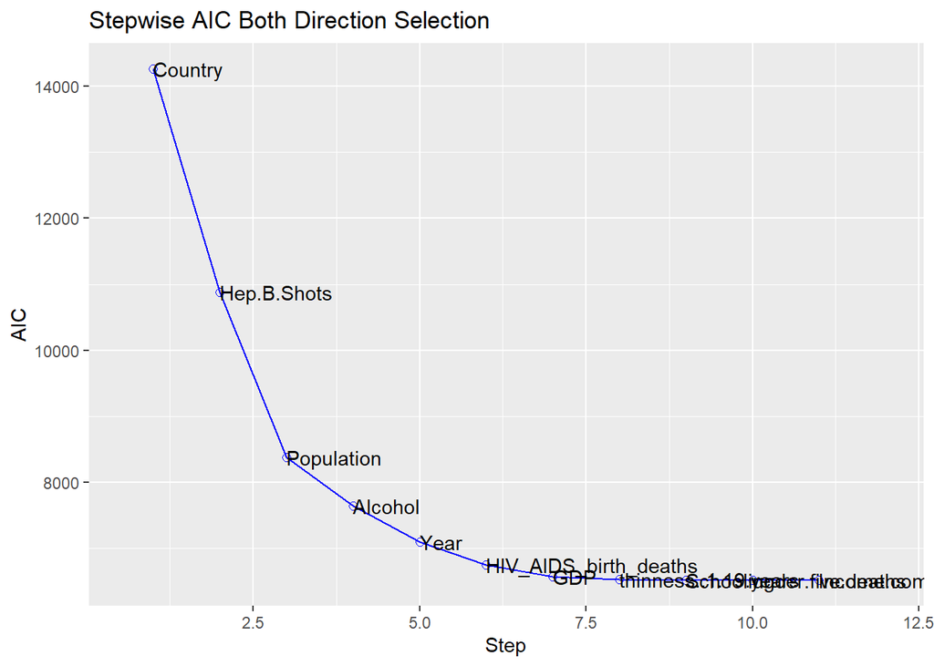

```r
plot(model_stpwise_aic)
```

```r
model_stpwise_p
```

```
##
##                                            Stepwise Selection Summary
## ----------------------------------------------------------------------------------------------------------------
##                                             Added/                   Adj.
## Step               Variable                Removed     R-Square    R-Square      C(p)          AIC         RMSE
## ----------------------------------------------------------------------------------------------------------------
##    1                Country                addition       0.938       0.934    2637.3190    12892.1773    2.4079
##    2            Adult.Mortality            addition       0.954       0.951    1249.6820    12097.8175    2.0808
##    3    Income.composition.of.resources    removal        0.954       0.951    1248.7790    12096.5753    2.0807
##    4               Schooling               addition       0.961       0.958     617.1570    11622.0961    1.9094
##    5                 Year                  addition       0.961       0.958     580.4460    11518.4509    1.9004
##    6    Income.composition.of.resources    addition       0.962       0.959     564.3360    11505.3944    1.8956
##    7         HIV_AIDS_birth_deaths         addition       0.962       0.959     506.8100    10788.6882    1.8926
##    8           Diphtheria_shots            addition       0.963       0.960     495.9350    10779.8438    1.8890
##    9             Measle_Cases              addition       0.963       0.960     474.9720    10739.1386    1.8828
## ----------------------------------------------------------------------------------------------------------------
```

```r
model_stpwise_aic
```

```
##
##
##                                               Stepwise Summary
## -----------------------------------------------------------------------------------------------------------
## Variable                            Method        AIC          RSS         Sum Sq       R-Sq      Adj. R-Sq
## -----------------------------------------------------------------------------------------------------------
## Country                            addition    14265.709    19745.542    245745.217    0.92563      0.92070
## Hep.B.Shots                        addition    10878.155    11695.281    156826.468    0.93060      0.92511
## Population                         addition     8383.805     9491.121    127336.965    0.93063      0.92497
## Alcohol                            addition     7649.150     8084.968    120081.564    0.93692      0.93132
## Year                               addition     7097.061     5705.611    122460.921    0.95548      0.95105
## HIV_AIDS_birth_deaths              addition     6747.364     4622.118    123544.414    0.96394      0.96032
## GDP                                addition     6576.309     4243.965    123720.193    0.96683      0.96346
## thinness..1.19.years               addition     6532.334     4202.545    123326.766    0.96705      0.96367
## Schooling                          addition     6517.378     4159.553    123369.759    0.96738      0.96402
## under.five.deaths                  addition     6516.688     4152.774    123376.537    0.96744      0.96406
## Income.composition.of.resources    addition     6516.217     4146.556    123382.755    0.96749      0.96409
## -----------------------------------------------------------------------------------------------------------
```

Get out the whip and use a little LASSO ### LASSO

```r
# Create a data subset because slicing an existing data frame to make a matrix is
# a huge pain in the keyboard
# Removing Country because the amount of factors scews the data
life_exp_train_v06 <- subset(life_exp_train_v05, select=c(-Country))

# Solve for missing data using mice
life_exp_train_v06_mice <- mice(life_exp_train_v06, seed=1234, method="cart")
```

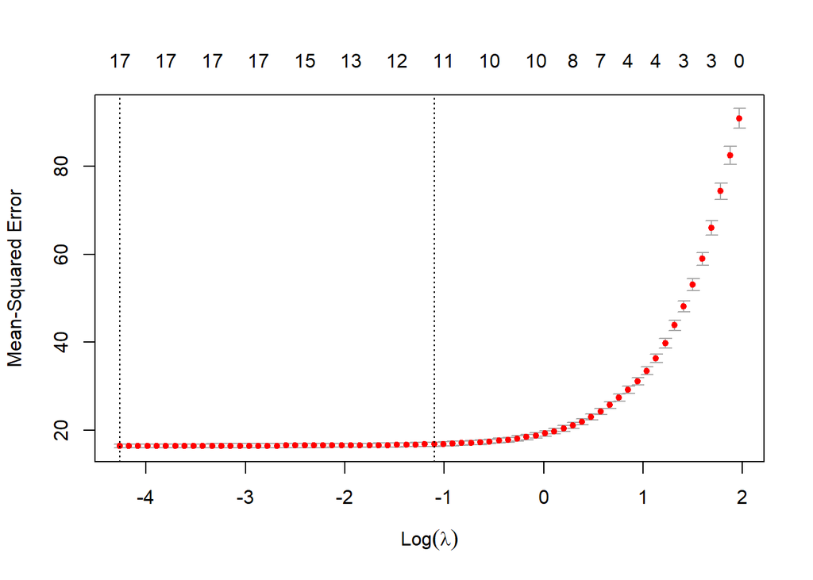

```r
life_exp_train_v06 <- complete(life_exp_train_v06_mice)

# Split the data
if (split_data == FALSE) {
  # Sperate the data
  set.seed(1536)
  split_size <- floor(0.85 * nrow(life_exp_train_v06))
  train_ind <- sample(seq_len(nrow(life_exp_train_v06)), size = split_size)
  life_exp_train_v06_final <- life_exp_train_v06[train_ind,]
  life_exp_test <- life_exp_train_v06[-train_ind,]
}

# Remove life expectancy for the matrix for glmnet. Built off v06_final
life_exp_train_v06.1 <- subset(life_exp_train_v06_final, select=c(-Life.expectancy))

# Matrix for glmnet
lasso_y <- life_exp_train_v06_final$Life.expectancy

# Define varaibles outside of the Lasso function
lasso_x <- data.matrix(life_exp_train_v06.1)

# Lasso model
life_cv_model <- cv.glmnet(lasso_x, lasso_y, alpha=1)
plot(life_cv_model)
```

```r
# Show Coefficients
coef(life_cv_model)
```

```
## 18 x 1 sparse Matrix of class "dgCMatrix"
##                                            s1
## (Intercept)                     52.7770318940
## Year                             .
## Status                          -0.8804637808
## Adult.Mortality                 -0.0175891320
## Alcohol                          .
## Hep.B.Shots                      .
## Measle_Cases                     .
## BMI                              0.0286232333
## under.five.deaths               -0.0004060704
## Polio_Shots                      0.0230672261
## Total_health_Spending            .
## Diphtheria_shots                 0.0324174435
## HIV_AIDS_birth_deaths           -0.4490995415
## GDP                              0.4284854784
## Population                       .
## thinness..1.19.years            -0.0546049123
## Income.composition.of.resources  6.7980691811
## Schooling                        0.7461336003
```

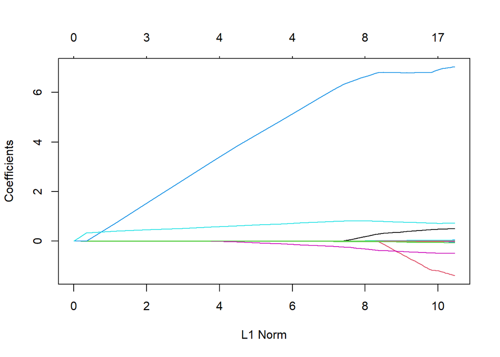

```r
plot(life_cv_model$glmnet.fit)
```

Create a prediction with the _test

```r
# Remove variables from test
life_exp_test_no_l.e = subset(life_exp_test, select=c(-Life.expectancy))
# Predict
life_exp_pred = predict(life_cv_model, data.matrix(life_exp_test_no_l.e))
# Convert back to data frame
life_exp_pred <- as.data.frame(life_exp_pred)

# List original values against predicted values
life_cv_pred_results <- data.frame(original=life_exp_test$Life.expectancy,
                                   predicted=life_exp_pred$lambda.1se)

# Check summary of model
summary(life_cv_pred_results)
```

```
##     original       predicted
##  Min.   :44.30   Min.   :37.09
##  1st Qu.:62.10   1st Qu.:62.99
##  Median :71.95   Median :70.93
##  Mean   :68.98   Mean   :69.16
##  3rd Qu.:75.40   3rd Qu.:75.26
##  Max.   :89.00   Max.   :85.02
```

```r
# Get RMSE
pred_rsme <- sqrt(mean((life_cv_pred_results$original - life_cv_pred_results$predicted)^2))
paste("The RMSE = ", as.character(pred_rsme), sep=' ') # 3.88
```

```
## [1] "The RMSE =  3.88407893724158"
```

### Objective 2

We’re going to try out a KNN model for Objective 2.

```r
library(caret)
#I'm using the output from the split below but renaming to help differentiate in the knn model to prevent confusion from here and there
#Converting the factors to numeric on the level to prevent NAs by coercion in Knn.
life_exp_train_v06_final$Year <- as.numeric(as.integer(factor(life_exp_train_v06_final$Year)))
life_exp_train_v06_final$Status <- as.numeric(as.integer(factor(life_exp_train_v06_final$Status)))
life_exp_test$Year <- as.numeric(as.integer(factor(life_exp_test$Year)))
life_exp_test$Status <- as.numeric(as.integer(factor(life_exp_test$Status)))
train_pred <- subset(life_exp_train_v06_final, select=c(-Life.expectancy))
train_out <- life_exp_train_v06_final$Life.expectancy
test_pred <- subset(life_exp_test, select=c(-Life.expectancy))
test_out <- life_exp_test$Life.expectancy
#train a knn model
le.knn <- knnreg(train_pred, train_out)
#predict the test life expectancy
predicted_test <- predict(le.knn, data.frame(test_pred))
#output the MSE, MAE, and RMSE
cat("MSE: ", mean((test_out - predicted_test)^2), " MAE: ", caret::MAE(test_out, predicted_test), " RMSE: ", caret::RMSE(test_out, predicted_test))
```

```
## MSE:  89.02514  MAE:  7.304659  RMSE:  9.435314
```

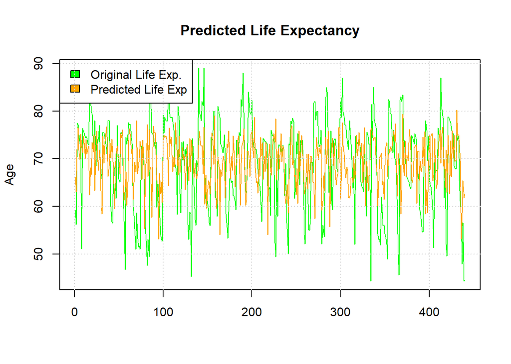

```r
#create a plot of the results of the knn model.
x_value <- 1:length(test_out)
plot(x_value, test_out, col="Green", type="l", lwd=1, main="Predicted Life Expectancy", xlab="", ylab="Age")
lines(x_value, predicted_test, col="Orange", lwd=1)
legend("topleft", legend=c("Original Life Exp.", "Predicted Life Exp"), fill = c("Green", "Orange"), col=2:3, adj=c(0,0.5))
grid()
```